# Angeline Chen

Biostatistic MS, Columbia University Mailman School of Public Health

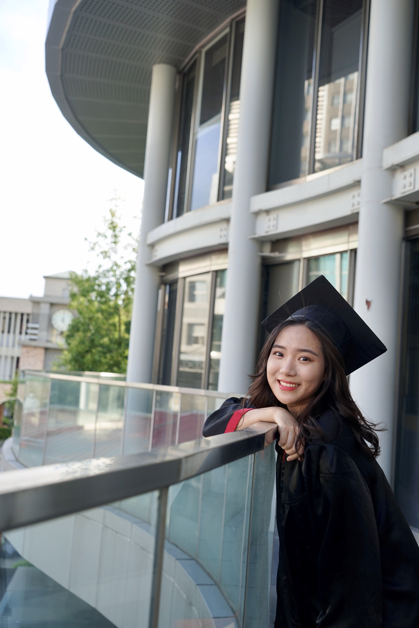

### About

I received a BS in Nutrition and Health Science and graduated from [Taipei Medical University](http://eng.tmu.edu.tw/) in 2019. I am now currently a first-year MS student in the Department of Biostatistics at [Columbia University](https://www.columbia.edu/).

### WORK EXPERIENCE

[Medtronic](https://www.medtronic.com/us-en/index.html)

Position: Intern in Sales Force Effectiveness & Key Account Management Department (Feb 2019 – Feb 2020)

• Resolved issues in Unique Device Identifier code for business units and key account hospitals in Taiwan; developed solutions through collecting, managing, analyzing and interpreting data.

[Taipei City Hospital](https://english.tch.gov.taipei/)

Position: Dietetic Intern (Jul 2018 – Dec 2018)

• Provided care/counseling for patients through nutrition assessment, diagnosis, intervention, monitoring, evaluation. • Delivered weekly public speech about healthcare education to patients and visitors. • Organized nutrition and meal plan activities for local community.

[Center Ventures](https://www.centerventures.com.tw/en)

Position: Summer Intern (Summer 2017) • Participated in a four-week boot camp taught by C-suite executives about business aspects in bio-tech and bio-medical field, focusing on investing in new medical technologies and drugs.

### Contact Information

Angeline Chen

[Department of Biostatistics](https://www.publichealth.columbia.edu/academics/departments/biostatistics)  
[Columbia Mailman School of Public Health](http://www.mailman.columbia.edu/)

Email: mc4959@cumc.columbia.edu

GitHub: https://github.com/meijuchen